# Course Project Demo

Jue Wang

```r
library(tidyverse)
```

```r
library(dplyr)
library(ggplot2)
library(readr)
library(tidyverse)
library(caret)
library(xgboost)
library(pROC)
```

# Overview

Try not to print raw R outputs but make the result as in **a clean and readable report**.

Lots of the figures in the file serve as exploration of the data. Try not to include the same figures from this demonstration file in your own report. Think about how to plot the figures **more concisely**. If you decide to include some of the figures/tables from this file, please include detailed explanation of the figures/tables and **what is your find out** from the figures/tables.

# Data structure

A total of 18 RDS files are provided that contain the records from 18 sessions. In each RDS file, you can find the name of mouse from `mouse_name` and date of the experiment from `date_exp`.

```r
session=list()
for(i in 1:18){
  session[[i]]=readRDS(paste('./Data/session',i,'.rds',sep=''))
  print(session[[i]]$mouse_name)

  print(session[[i]]$date_exp)

}
```

```
## [1] "Cori"
## [1] "2016-12-14"
## [1] "Cori"
## [1] "2016-12-17"
## [1] "Cori"
## [1] "2016-12-18"
## [1] "Forssmann"
## [1] "2017-11-01"
## [1] "Forssmann"
## [1] "2017-11-02"
## [1] "Forssmann"
## [1] "2017-11-04"
## [1] "Forssmann"
## [1] "2017-11-05"
## [1] "Hench"
```

[output cut: 21 more lines]

## What’s in a session?

```r
names(session[[1]])
```

```
## [1] "contrast_left"  "contrast_right" "feedback_type"  "mouse_name"
## [5] "brain_area"     "date_exp"       "spks"           "time"
```

## What’s in a trail?

```r
dim(session[[1]]$spks[[1]])
```

```
## [1] 734  40
```

```r
length(session[[1]]$brain_area)
```

```
## [1] 734
```

```r
session[[1]]$spks[[1]][6,] # Each row contains 40 time bins.
```

```
##  [1] 0 0 1 0 0 0 1 0 0 0 0 0 0 0 0 0 0 0 0 0 0 0 1 0 0 0 0 0 0 0 0 0 0 0 0 0 0 0
## [39] 0 0
```

## How to connect the neuron spike with brain region?

```r
session[[1]]$spks[[1]][6,3]
```

```
## [1] 1
```

```r
session[[1]]$brain_area[6]
```

```
## [1] "ACA"
```

The above information tells us in session 1 trail 1, the 6 neuron (from area ACA) has a spike at time bin 3.

# Data processing

I denote the `spike rate` per neuron as the sum of spikes over the 40 time bins. The `region_mean_spike` records the average of spike rate over each region.

```r
get_trail_data <- function(session_id, trail_id){
  spikes <- session[[session_id]]$spks[[trail_id]]
  if (any(is.na(spikes))){
    disp("value missing")
  }

  #trail_tibble <- as_tibble(spikes) %>% set_names(binename) %>%  add_column("brain_area" = session[[session_id]]$brain_area ) %>% group_by(brain_area) %>% summarize( "sum_spikes" =across(everything(),sum),.groups = "drop")
  trail_tibble <- tibble("neuron_spike" = rowSums(spikes))  %>%  add_column("brain_area" = session[[session_id]]$brain_area ) %>% group_by(brain_area) %>% summarize( region_sum_spike = sum(neuron_spike), region_count = n(),region_mean_spike = mean(neuron_spike))
  trail_tibble  = trail_tibble%>% add_column("trail_id" = trail_id) %>% add_column("contrast_left"= session[[session_id]]$contrast_left[trail_id]) %>% add_column("contrast_right"= session[[session_id]]$contrast_right[trail_id]) %>% add_column("feedback_type"= session[[session_id]]$feedback_type[trail_id])
  trail_tibble
}
```

```r
trail_tibble_1_2 <- get_trail_data(1,2)
trail_tibble_1_2
```

```
## # A tibble: 8 × 8
##   brain_area region_sum_spike region_count region_mean_spike trail_id
##   <chr>                 <dbl>        <int>             <dbl>    <dbl>
## 1 ACA                      64          109             0.587        2
## 2 CA3                     116           68             1.71         2
## 3 DG                       53           34             1.56         2
## 4 LS                      190          139             1.37         2
## 5 MOs                      88          113             0.779        2
## 6 SUB                     146           75             1.95         2
## 7 VISp                    294          178             1.65         2
## 8 root                     12           18             0.667        2
## # ℹ 3 more variables: contrast_left <dbl>, contrast_right <dbl>,
## #   feedback_type <dbl>
```

```r
session_1 <- get_session_data(1)
head(session_1)
```

```
## # A tibble: 6 × 11
##   brain_area region_sum_spike region_count region_mean_spike trail_id
##   <chr>                 <dbl>        <int>             <dbl>    <int>
## 1 ACA                     138          109             1.27         1
## 2 CA3                     104           68             1.53         1
## 3 DG                       79           34             2.32         1
## 4 LS                      269          139             1.94         1
## 5 MOs                     106          113             0.938        1
## 6 SUB                     156           75             2.08         1
## # ℹ 6 more variables: contrast_left <dbl>, contrast_right <dbl>,
## #   feedback_type <dbl>, mouse_name <chr>, date_exp <chr>, session_id <dbl>
```

Here is another way of data processing. For each trail, I take the average of neuron spikes over each time bin. I denote it as `trail_bin_average`

In the following table, each row contains information of a particular trail. The columns contains the average spike rate for each time bin.

```
## # A tibble: 6 × 49
##     bin1   bin2   bin3   bin4   bin5   bin6   bin7   bin8   bin9  bin10  bin11
##    <dbl>  <dbl>  <dbl>  <dbl>  <dbl>  <dbl>  <dbl>  <dbl>  <dbl>  <dbl>  <dbl>
## 1 0.0490 0.0368 0.0177 0.0150 0.0327 0.0286 0.0313 0.0123 0.0341 0.0191 0.0463
## 2 0.0300 0.0313 0.0341 0.0272 0.0259 0.0313 0.0218 0.0232 0.0232 0.0341 0.0272
## 3 0.0490 0.0504 0.0300 0.0436 0.0245 0.0409 0.0300 0.0381 0.0341 0.0422 0.0559
## 4 0.0559 0.0531 0.0272 0.0613 0.0572 0.0599 0.0450 0.0286 0.0395 0.0354 0.0368
## 5 0.0272 0.0436 0.0313 0.0245 0.0450 0.0381 0.0463 0.0572 0.0477 0.0163 0.0272
## 6 0.0490 0.0218 0.0163 0.0109 0.0123 0.0232 0.0272 0.0327 0.0163 0.0191 0.0300
## # ℹ 38 more variables: bin12 <dbl>, bin13 <dbl>, bin14 <dbl>, bin15 <dbl>,
## #   bin16 <dbl>, bin17 <dbl>, bin18 <dbl>, bin19 <dbl>, bin20 <dbl>,
## #   bin21 <dbl>, bin22 <dbl>, bin23 <dbl>, bin24 <dbl>, bin25 <dbl>,
## #   bin26 <dbl>, bin27 <dbl>, bin28 <dbl>, bin29 <dbl>, bin30 <dbl>,
## #   bin31 <dbl>, bin32 <dbl>, bin33 <dbl>, bin34 <dbl>, bin35 <dbl>,
## #   bin36 <dbl>, bin37 <dbl>, bin38 <dbl>, bin39 <dbl>, bin40 <dbl>,
## #   trail_id <int>, contrast_left <dbl>, contrast_right <dbl>, …
```

# EDA

**Goal of EDA**:

0. Final task is to predict the results of random trails from session 1 and session 18.
1. What are some interesting patterns of the data, especially the similarity and difference among different observations (trails). This will answer the question of how to select our training samples.
2. What patterns make a trail more likely to have a successful respinse. This will answer the question of how to build our training features.

## What is different for each session/mouse

### What are the number of neuron’s in each session?

```
## # A tibble: 18 × 2
##    session_id `sum(region_count)`
##         <int>               <int>
##  1          1                 734
##  2          2                1070
##  3          3                 619
##  4          4                1769
##  5          5                1077
##  6          6                1169
##  7          7                 584
##  8          8                1157
##  9          9                 788
## 10         10                1172
## 11         11                 857
## 12         12                 698
## 13         13                 983
## 14         14                 756
## 15         15                 743
## 16         16                 474
## 17         17                 565
## 18         18                1090
```

### What is the number brain area of each session

```
## # A tibble: 18 × 2
##    session_id unique_area
##         <int>       <int>
##  1          1           8
##  2          2           5
##  3          3          11
##  4          4          11
##  5          5          10
##  6          6           5
##  7          7           8
##  8          8          15
##  9          9          12
## 10         10          13
## 11         11           6
## 12         12          12
## 13         13          15
## 14         14          10
## 15         15           8
## 16         16           6
## 17         17           6
## 18         18          10
```

### What is the average spike rate over each session

```
## # A tibble: 18 × 2
##    session_id mean_session_spike
##         <int>              <dbl>
##  1          1              1.54
##  2          2              1.27
##  3          3              2.23
##  4          4              0.842
##  5          5              1.12
##  6          6              0.663
##  7          7              1.42
##  8          8              1.66
##  9          9              1.59
## 10         10              1.19
## 11         11              1.25
## 12         12              1.66
## 13         13              2.46
## 14         14              1.01
## 15         15              1.46
## 16         16              1.05
## 17         17              1.17
## 18         18              1.10
```

### What are the brain areas with neurons recorded in each session?

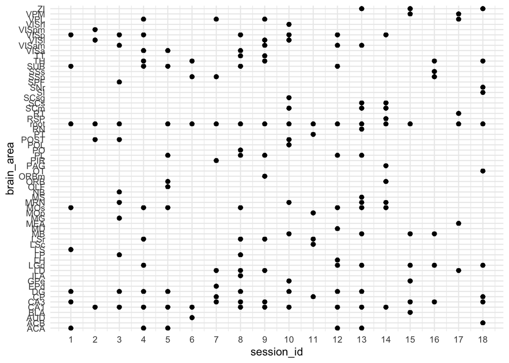

### Estimate success rate over different groups (session and mouse)

```
## # A tibble: 18 × 2
##    session_id success_rate
##    <fct>             <dbl>
##  1 1                 0.605
##  2 2                 0.633
##  3 3                 0.662
##  4 4                 0.667
##  5 5                 0.661
##  6 6                 0.741
##  7 7                 0.671
##  8 8                 0.644
##  9 9                 0.685
## 10 10                0.620
## 11 11                0.795
## 12 12                0.738
## 13 13                0.797
## 14 14                0.694
## 15 15                0.765
## 16 16                0.718
## 17 17                0.830
## 18 18                0.806
```

```
## # A tibble: 4 × 2
##   mouse_name success_rate
##   <chr>             <dbl>
## 1 Cori              0.639
## 2 Forssmann         0.687
## 3 Hench             0.684
## 4 Lederberg         0.761
```

## What is different among each trail?

### What is the contrast difference distribution?

```
## # A tibble: 5 × 4
##   contrast_diff     n  perc labels
##           <dbl> <int> <dbl> <chr>
## 1          0.25   718 0.141 14.13%
## 2          0.75   740 0.146 14.56%
## 3          1      892 0.176 17.56%
## 4          0.5   1045 0.206 20.57%
## 5          0     1686 0.332 33.18%
```

### How does the contrast difference affect the success rate?

```
## # A tibble: 5 × 2
##   contrast_diff success_rate
##           <dbl>        <dbl>
## 1          0           0.629
## 2          0.25        0.667
## 3          0.5         0.777
## 4          0.75        0.741
## 5          1           0.795
```

### Does the success rate difference among mice caused by the different distributions of contrast difference?

```
##            contrast_diff
## mouse_name           0       0.25        0.5       0.75          1
##   Cori      0.36256324 0.08768971 0.20236088 0.13153457 0.21585160
##   Forssmann 0.36555024 0.20095694 0.19425837 0.13301435 0.10622010
##   Hench     0.28773919 0.13465627 0.21190645 0.13182140 0.23387668
##   Lederberg 0.33612205 0.13090551 0.20816929 0.16584646 0.15895669
```

Can you use two-way ANOVA to answer the above question more rigorously?

### Visualize success rate change over time (trail)

The success rate is binned for each 25 trails.

The success rate change over time for individual sessions:

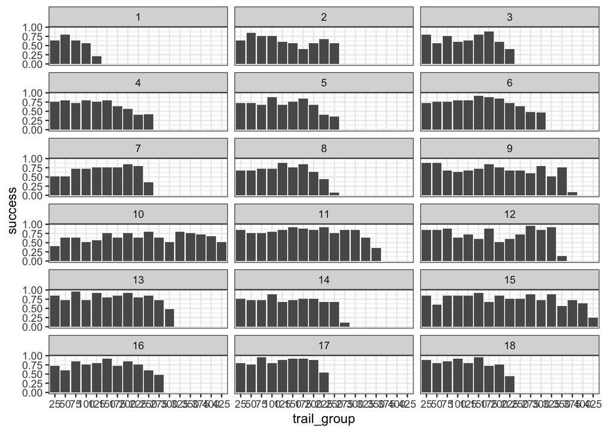

The success rate change over time for individual mouse:

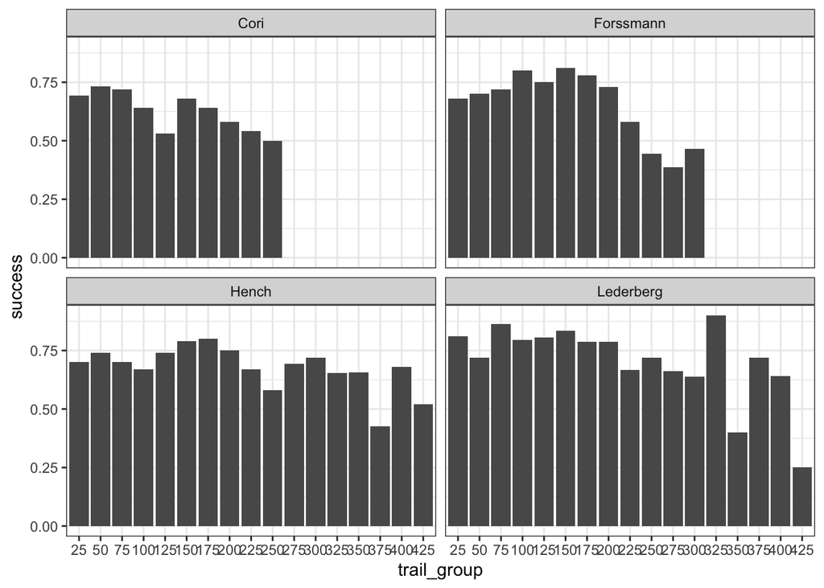

### Visualize the change of overall neuron spike rate over time

The `average_spike` is the number of spikes within each number bin divided total number of neurons for each trail.

The change of overall neuron spike rate for each session

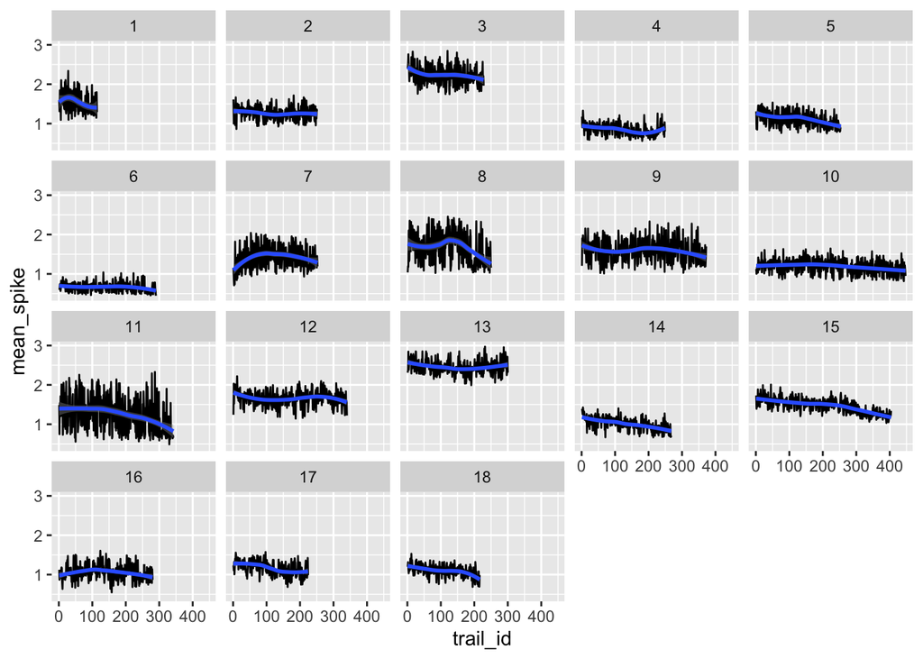

The change of overall neuron spike rate for each mouse

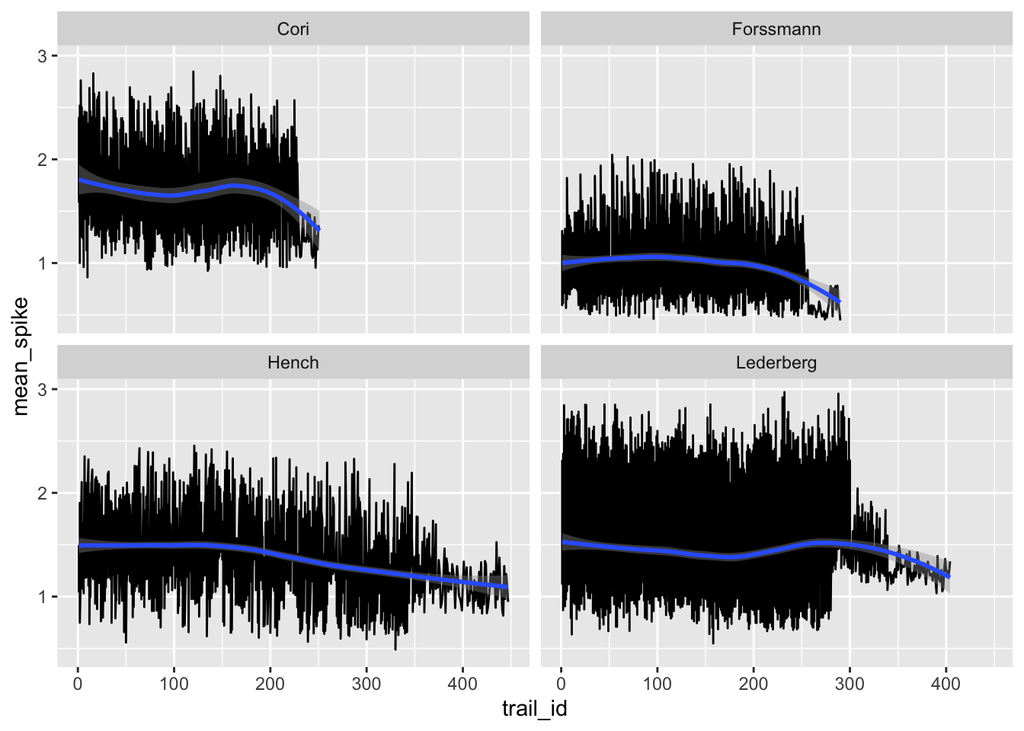

# Dimension Reduction through PCA

We perform PCA and visualize the 2D results.

The dots are colored for different session.

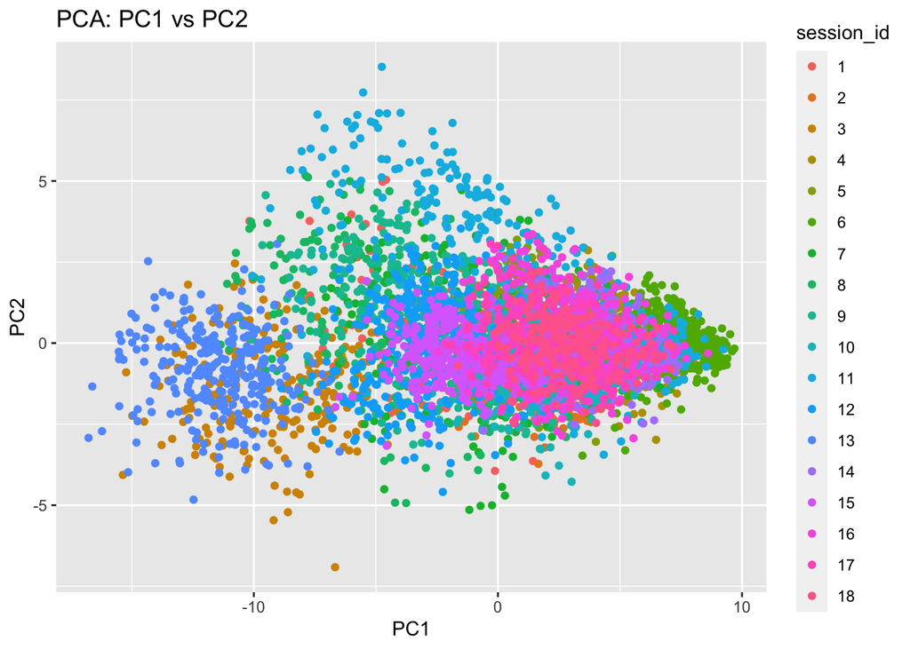

The dots are colored for different mouse

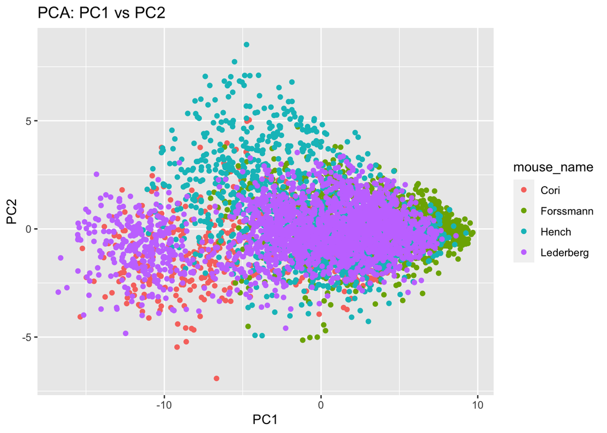

What can be found through these two plots?

# Data Integration

I decide to use trails from all sessions first and see the performance. The feature I decide to use are session_id, trail_id, signals, and the average spike rate of each time bin.

```r
predictive_feature <- c("session_id","trail_id","contrast_right","contrast_left", "contrast_diff" ,binename)
head(full_functional_tibble[predictive_feature])
```

```
## # A tibble: 6 × 45
##   session_id trail_id contrast_right contrast_left contrast_diff   bin1   bin2
##   <fct>         <int>          <dbl>         <dbl>         <dbl>  <dbl>  <dbl>
## 1 1                 1            0.5           0             0.5 0.0490 0.0368
## 2 1                 2            0             0             0   0.0300 0.0313
## 3 1                 3            1             0.5           0.5 0.0490 0.0504
## 4 1                 4            0             0             0   0.0559 0.0531
## 5 1                 5            0             0             0   0.0272 0.0436
## 6 1                 6            0             0             0   0.0490 0.0218
## # ℹ 38 more variables: bin3 <dbl>, bin4 <dbl>, bin5 <dbl>, bin6 <dbl>,
## #   bin7 <dbl>, bin8 <dbl>, bin9 <dbl>, bin10 <dbl>, bin11 <dbl>, bin12 <dbl>,
## #   bin13 <dbl>, bin14 <dbl>, bin15 <dbl>, bin16 <dbl>, bin17 <dbl>,
## #   bin18 <dbl>, bin19 <dbl>, bin20 <dbl>, bin21 <dbl>, bin22 <dbl>,
## #   bin23 <dbl>, bin24 <dbl>, bin25 <dbl>, bin26 <dbl>, bin27 <dbl>,
## #   bin28 <dbl>, bin29 <dbl>, bin30 <dbl>, bin31 <dbl>, bin32 <dbl>,
## #   bin33 <dbl>, bin34 <dbl>, bin35 <dbl>, bin36 <dbl>, bin37 <dbl>, …
```

# Prediction

## train the model on 80% trails and test it on the rest

```r
# split
set.seed(123) # for reproducibility
trainIndex <- createDataPartition(label, p = .8,
                                  list = FALSE,
                                  times = 1)
train_df <- predictive_dat[trainIndex, ]
train_X <- X[trainIndex,]
test_df <- predictive_dat[-trainIndex, ]
test_X <- X[-trainIndex,]

train_label <- label[trainIndex]
test_label <- label[-trainIndex]
```

I decide to go with xgboost because I have lots of features, I expect there are some interactions among those interactions, and I have a relative large training set to avoid overfitting.

```r
xgb_model <- xgboost(data = train_X, label = train_label, objective = "binary:logistic", nrounds=10)
```

Prediction results (accuracy, confusion matrix, AUROC)

```r
predictions <- predict(xgb_model, newdata = test_X)
predicted_labels <- as.numeric(ifelse(predictions > 0.5, 1, 0))
accuracy <- mean(predicted_labels == test_label)
accuracy
```

```
## [1] 0.7312992
```

```r
conf_matrix <- confusionMatrix(as.factor(predicted_labels), as.factor(test_label))
conf_matrix$table
```

```
##           Reference
## Prediction   0   1
##          0  76  52
##          1 221 667
```

```r
auroc <- roc(test_label, predictions)
auroc
```

```
##
## Call:
## roc.default(response = test_label, predictor = predictions)
##
## Data: predictions in 297 controls (test_label 0) < 719 cases (test_label 1).
## Area under the curve: 0.7379
```

## test the model’s performance on 50 random trails from session 18

```r
# split
set.seed(123) # for reproducibility
session_18_row <- which(full_functional_tibble$session_id==18)
testIndex <- sample(session_18_row, 50, replace = FALSE)
trainIndex <- 1:nrow(full_functional_tibble)
trainIndex <- trainIndex[!(trainIndex %in% testIndex)]

train_df <- predictive_dat[trainIndex, ]
train_X <- X[trainIndex,]
test_df <- predictive_dat[-trainIndex, ]
test_X <- X[-trainIndex,]

train_label <- label[trainIndex]
test_label <- label[-trainIndex]
```

Prediction results (accuracy, confusion matrix, AUROC)

```r
xgb_model <- xgboost(data = train_X, label = train_label, objective = "binary:logistic", nrounds=10)
predictions <- predict(xgb_model, newdata = test_X)
predicted_labels <- as.numeric(ifelse(predictions > 0.5, 1, 0))
accuracy <- mean(predicted_labels == test_label)
accuracy
```

```
## [1] 0.8
```

```r
conf_matrix <- confusionMatrix(as.factor(predicted_labels), as.factor(test_label))
conf_matrix$table
```

```
##           Reference
## Prediction  0  1
##          0  1  1
##          1  9 39
```

```r
auroc <- roc(test_label, predictions)
auroc
```

```
##
## Call:
## roc.default(response = test_label, predictor = predictions)
##
## Data: predictions in 10 controls (test_label 0) < 40 cases (test_label 1).
## Area under the curve: 0.6875
```

## test the model’s performance on 50 random trails from session 1

Prediction results (accuracy, confusion matrix, AUROC)

```
## [1] 0.66
```

```
##           Reference
## Prediction  0  1
##          0  2  0
##          1 17 31
```

```
##
## Call:
## roc.default(response = test_label, predictor = predictions)
##
## Data: predictions in 19 controls (test_label 0) < 31 cases (test_label 1).
## Area under the curve: 0.6689
```

# Project milestones

A series of milestones are set throughout the quarter in order to encourage, and reward, early starts on the course project. Furthermore, there are several project discussion sessions throughout the quarter for students to utilize.

- Project proposal January 26th (optional): 0 points. Students are **strongly recommended** to attend the project discussion during the regular lecture time on Zoom.
- Milestone I February 9th (optional): 0 points but eligible for bonus points for outstanding progress or novel findings. Draft analysis and results for Part I visualization. Students are **recommended** to attend the optional project discussion during the regular lecture time on Zoom.
- Milestone II March 1st (optional): 0 points but eligible for bonus points for outstanding progress or novel findings. Draft analysis and results for Part II data integration. Students are **recommended** to attend the optional project discussion during the regular lecture time on Zoom.
- March 18th Project report: 60 points. Students are **strongly recommended** to attend at least one project consulting session in Week 10.

# Reference

Steinmetz, N.A., Zatka-Haas, P., Carandini, M. et al. Distributed coding of choice, action and engagement across the mouse brain. Nature 576, 266–273 (2019). https://doi.org/10.1038/s41586-019-1787-x